# Assognment_5

```r
## All files for this assignment can be found at https://github.com/Dylan-Hamilton3412/64060_-Dhamil28
## Install and library required packages for this assignment
library(ISLR)
library(dplyr)
library(cluster)
library(stats)
library(readr)
library(class)
library(caret)

## Set a seed to ensure reproducibility
set.seed(123)

## Import the cereal data set and examine the variables
Cereal_Data <- read.csv("Cereals.csv")
summary(Cereal_Data)
```

```
     name               mfr                type              calories        protein           fat
 Length:77          Length:77          Length:77          Min.   : 50.0   Min.   :1.000   Min.   :0.000
 Class :character   Class :character   Class :character   1st Qu.:100.0   1st Qu.:2.000   1st Qu.:0.000
 Mode  :character   Mode  :character   Mode  :character   Median :110.0   Median :3.000   Median :1.000
                                                          Mean   :106.9   Mean   :2.545   Mean   :1.013
                                                          3rd Qu.:110.0   3rd Qu.:3.000   3rd Qu.:2.000
                                                          Max.   :160.0   Max.   :6.000   Max.   :5.000

     sodium          fiber            carbo          sugars           potass          vitamins
 Min.   :  0.0   Min.   : 0.000   Min.   : 5.0   Min.   : 0.000   Min.   : 15.00   Min.   :  0.00
 1st Qu.:130.0   1st Qu.: 1.000   1st Qu.:12.0   1st Qu.: 3.000   1st Qu.: 42.50   1st Qu.: 25.00
 Median :180.0   Median : 2.000   Median :14.5   Median : 7.000   Median : 90.00   Median : 25.00
 Mean   :159.7   Mean   : 2.152   Mean   :14.8   Mean   : 7.026   Mean   : 98.67   Mean   : 28.25
 3rd Qu.:210.0   3rd Qu.: 3.000   3rd Qu.:17.0   3rd Qu.:11.000   3rd Qu.:120.00   3rd Qu.: 25.00
 Max.   :320.0   Max.   :14.000   Max.   :23.0   Max.   :15.000   Max.   :330.00   Max.   :100.00
                                  NA's   :1      NA's   :1        NA's   :2
     shelf           weight          cups           rating
 Min.   :1.000   Min.   :0.50   Min.   :0.250   Min.   :18.04
 1st Qu.:1.000   1st Qu.:1.00   1st Qu.:0.670   1st Qu.:33.17
 Median :2.000   Median :1.00   Median :0.750   Median :40.40
 Mean   :2.208   Mean   :1.03   Mean   :0.821   Mean   :42.67
 3rd Qu.:3.000   3rd Qu.:1.00   3rd Qu.:1.000   3rd Qu.:50.83
 Max.   :3.000   Max.   :1.50   Max.   :1.500   Max.   :93.70
```

```r
## From summarizing the data we can see there are a few NA variables located in the Data set

## Remove cereals with missing values to ensure all observations can be clustered
Cereal_Data <- na.omit(Cereal_Data)
summary(Cereal_Data)
```

```
     name               mfr                type              calories      protein           fat
 Length:74          Length:74          Length:74          Min.   : 50   Min.   :1.000   Min.   :0
 Class :character   Class :character   Class :character   1st Qu.:100   1st Qu.:2.000   1st Qu.:0
 Mode  :character   Mode  :character   Mode  :character   Median :110   Median :2.500   Median :1
                                                          Mean   :107   Mean   :2.514   Mean   :1
                                                          3rd Qu.:110   3rd Qu.:3.000   3rd Qu.:1
                                                          Max.   :160   Max.   :6.000   Max.   :5
     sodium          fiber            carbo           sugars           potass          vitamins
 Min.   :  0.0   Min.   : 0.000   Min.   : 5.00   Min.   : 0.000   Min.   : 15.00   Min.   :  0.00
 1st Qu.:135.0   1st Qu.: 0.250   1st Qu.:12.00   1st Qu.: 3.000   1st Qu.: 41.25   1st Qu.: 25.00
 Median :180.0   Median : 2.000   Median :14.50   Median : 7.000   Median : 90.00   Median : 25.00
 Mean   :162.4   Mean   : 2.176   Mean   :14.73   Mean   : 7.108   Mean   : 98.51   Mean   : 29.05
 3rd Qu.:217.5   3rd Qu.: 3.000   3rd Qu.:17.00   3rd Qu.:11.000   3rd Qu.:120.00   3rd Qu.: 25.00
 Max.   :320.0   Max.   :14.000   Max.   :23.00   Max.   :15.000   Max.   :330.00   Max.   :100.00
     shelf           weight           cups            rating
 Min.   :1.000   Min.   :0.500   Min.   :0.2500   Min.   :18.04
 1st Qu.:1.250   1st Qu.:1.000   1st Qu.:0.6700   1st Qu.:32.45
 Median :2.000   Median :1.000   Median :0.7500   Median :40.25
 Mean   :2.216   Mean   :1.031   Mean   :0.8216   Mean   :42.37
 3rd Qu.:3.000   3rd Qu.:1.000   3rd Qu.:1.0000   3rd Qu.:50.52
 Max.   :3.000   Max.   :1.500   Max.   :1.5000   Max.   :93.70
```

```r
## Convert categorical variables mfr and type into dummy variables
Dummy_vars <- dummyVars(~ mfr+type, data = Cereal_Data)
Cereal_Dummy_Var <- predict(Dummy_vars, newdata = Cereal_Data)
## Add the dummy variables back into the original data set
Cereal_Data <- cbind(Cereal_Data, Cereal_Dummy_Var)

## Remove the original categorical variables columns
Cereal_Data$mfr = NULL
Cereal_Data$type = NULL

## Use the cereal names as row labels so that the names are preserved
row.names(Cereal_Data) <- Cereal_Data[,1]
Cereal_Data <- Cereal_Data[,-1]

## Normalize the data using Z-score in order to not have one variable dominate the clustering algorithm
Cereal_Data <- scale(Cereal_Data)
Cereal_Data <- as.data.frame(Cereal_Data)
summary(Cereal_Data)
```

```
    calories          protein              fat              sodium            fiber
 Min.   :-2.8738   Min.   :-1.40687   Min.   :-0.9932   Min.   :-1.9616   Min.   :-0.89778
 1st Qu.:-0.3541   1st Qu.:-0.47733   1st Qu.:-0.9932   1st Qu.:-0.3306   1st Qu.:-0.79462
 Median : 0.1498   Median :-0.01256   Median : 0.0000   Median : 0.2131   Median :-0.07249
 Mean   : 0.0000   Mean   : 0.00000   Mean   : 0.0000   Mean   : 0.0000   Mean   : 0.00000
 3rd Qu.: 0.1498   3rd Qu.: 0.45221   3rd Qu.: 0.0000   3rd Qu.: 0.6661   3rd Qu.: 0.34015
 Max.   : 2.6695   Max.   : 3.24083   Max.   : 3.9729   Max.   : 1.9045   Max.   : 4.87925
     carbo              sugars            potass           vitamins           shelf
 Min.   :-2.50014   Min.   :-1.6306   Min.   :-1.1783   Min.   :-1.3032   Min.   :-1.4617
 1st Qu.:-0.70143   1st Qu.:-0.9424   1st Qu.:-0.8079   1st Qu.:-0.1818   1st Qu.:-1.1612
 Median :-0.05903   Median :-0.0248   Median :-0.1201   Median :-0.1818   Median :-0.2599
 Mean   : 0.00000   Mean   : 0.0000   Mean   : 0.0000   Mean   : 0.0000   Mean   : 0.0000
 3rd Qu.: 0.58337   3rd Qu.: 0.8928   3rd Qu.: 0.3031   3rd Qu.:-0.1818   3rd Qu.: 0.9420
 Max.   : 2.12512   Max.   : 1.8104   Max.   : 3.2660   Max.   : 3.1822   Max.   : 0.9420
     weight             cups             rating             mfrA              mfrG             mfrK
 Min.   :-3.4600   Min.   :-2.4251   Min.   :-1.7336   Min.   :-0.1162   Min.   :-0.646   Min.   :-0.667
 1st Qu.:-0.2008   1st Qu.:-0.6432   1st Qu.:-0.7071   1st Qu.:-0.1162   1st Qu.:-0.646   1st Qu.:-0.667
 Median :-0.2008   Median :-0.3038   Median :-0.1510   Median :-0.1162   Median :-0.646   Median :-0.667
 Mean   : 0.0000   Mean   : 0.0000   Mean   : 0.0000   Mean   : 0.0000   Mean   : 0.000   Mean   : 0.000
 3rd Qu.:-0.2008   3rd Qu.: 0.7568   3rd Qu.: 0.5807   3rd Qu.:-0.1162   3rd Qu.: 1.527   3rd Qu.: 1.479
 Max.   : 3.0583   Max.   : 2.8780   Max.   : 3.6578   Max.   : 8.4861   Max.   : 1.527   Max.   : 1.479
      mfrN              mfrP              mfrQ             mfrR            typeC             typeH
 Min.   :-0.2674   Min.   :-0.3696   Min.   :-0.321   Min.   :-0.321   Min.   :-8.4861   Min.   :-0.1162
 1st Qu.:-0.2674   1st Qu.:-0.3696   1st Qu.:-0.321   1st Qu.:-0.321   1st Qu.: 0.1162   1st Qu.:-0.1162
 Median :-0.2674   Median :-0.3696   Median :-0.321   Median :-0.321   Median : 0.1162   Median :-0.1162
 Mean   : 0.0000   Mean   : 0.0000   Mean   : 0.000   Mean   : 0.000   Mean   : 0.0000   Mean   : 0.0000
 3rd Qu.:-0.2674   3rd Qu.:-0.3696   3rd Qu.:-0.321   3rd Qu.:-0.321   3rd Qu.: 0.1162   3rd Qu.:-0.1162
 Max.   : 3.6896   Max.   : 2.6692   Max.   : 3.073   Max.   : 3.073   Max.   : 0.1162   Max.   : 8.4861
```

```r
## Compute the Euclidean distance matrix between cereals
Data_dist <- dist(Cereal_Data, method = "euclidean")

## Part A
## Compare four linkage methods using AGNES hierarchical clustering

##Single Linkage
HClust_Single <- agnes(Cereal_Data, method = "single")
HClust_Single$ac
```

```
[1] 0.8543243
```

```r
## Complete linkage
HClust_Complete <- agnes(Cereal_Data, method = "complete")
HClust_Complete$ac
```

```
[1] 0.8618592
```

```r
## Average linkage
HClust_Average <- agnes(Cereal_Data, method = "average")
HClust_Average$ac
```

```
[1] 0.8518632
```

```r
## Ward's linkage
HClust_Ward <- agnes(Cereal_Data, method = "ward")
HClust_Ward$ac
```

```
[1] 0.8853988
```

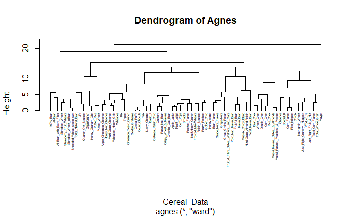

```r
## Ward's method produced the highest agglomerative coefficient (.88) this method will be used moving forward

## Display the dendrogram produced by Ward's method
pltree(HClust_Ward, cex = 0.4, hang = -1, main = "Dendrogram of Agnes")
```

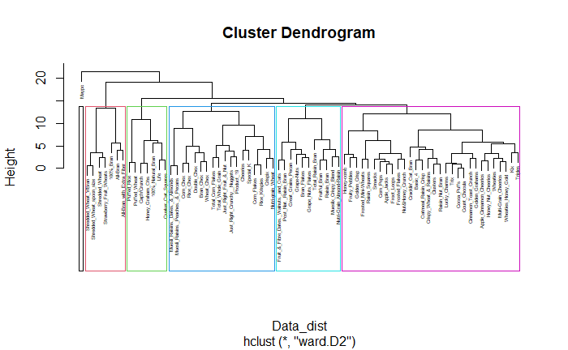

```r
## Part B

## Perform hierarchical clustering using Ward's method and Euclidean distance
Full_Cluster <- hclust(Data_dist, method = "ward.D2")

## Plot the dendrogram to determine an appropriate number of clusters
plot(Full_Cluster, cex = 0.4)

## Divide the dendrogram into six clusters
## Six clusters were chosen because they provided meaningful separation
rect.hclust(Full_Cluster, k = 6, border = 1:6)
```

```r
Cut_Cluster <- cutree(Full_Cluster, k = 6)

## Display the number of cereals contained in each cluster
table(Cut_Cluster)
```

```
Cut_Cluster
 1  2  3  4  5  6
 7  7 30 18 11  1
```

```r
## Part C

Index <- sample(1:nrow(Cereal_Data), .5*nrow(Cereal_Data))
Part_A <- Cereal_Data[Index,]
Part_B <- Cereal_Data[-Index,]

A_dist <- dist(Part_A, method = "euclidean")
A_Cluster <- hclust(A_dist, method = "ward.D2")
A_Cluster <- cutree(A_Cluster, k = 6)
table(A_Cluster)
```

```
A_Cluster
 1  2  3  4  5  6
10  5 14  1  5  2
```

```r
## Calculate the centroids of each cluster

A_Centroids <- aggregate(Part_A, by = list(Cluster = A_Cluster), mean)

## Remove the cluster labels and convert centroids to a matrix
Centroid_Matrix <- as.matrix(A_Centroids[, -1])

## Calculate distances between each observation in partition B and each cluster centroid
Distance_Matrix <- as.matrix(dist(rbind(Centroid_Matrix, Part_B)))

## Extract only the distances from centroids to observations in B
Distance_B <- Distance_Matrix[1:nrow(Centroid_Matrix), (nrow(Centroid_Matrix)+1):nrow(Distance_Matrix)]

## Assign each observation in partition B to the nearest centroid
B_Assignment <- apply(Distance_B, 2, which.min)

table(B_Assignment)
```

```
B_Assignment
 1  2  3  5  6
11  5 16  2  3
```

```r
## Examine the cluster assignments for observations in partition B
table(B_Assignment, Cut_Cluster[-Index])
```

```
B_Assignment 1 2 3 4 5
           1 0 2 4 4 1
           2 2 0 0 1 2
           3 0 3 9 4 0
           5 0 0 0 2 0
           6 3 0 0 0 0
```

To assess cluster stability, the data were randomly divided into two partitions. Cluster centroids obtained from partition A were used to assign observations in partition B, and these assignments were compared with the six-cluster solution obtained using the entire dataset. The comparison revealed moderate agreement between the two sets of assignments. While some clusters, particularly Cluster 3, showed reasonable consistency, many observations were assigned to different clusters when the full dataset was used. This suggests that the six-cluster solution captures some meaningful structure in the data, but the clusters are not highly stable and may be sensitive to the particular sample used. Therefore, the clustering solution exhibits moderate rather than strong stability.

```r
## Part D

Cereal_Data <- cbind(Cereal_Data, Cluster = as.factor(Cut_Cluster))
Cluster_Means <- aggregate(.~ Cluster, data = Cereal_Data, mean)
Cluster_Means
```

| Cluster | calories | protein | fat | sodium | fiber | carbo | sugars | potass | vitamins | shelf | weight | cups | rating | mfrA | mfrG | mfrK | mfrN | mfrP | mfrQ | mfrR | typeC | typeH |
| --- | --- | --- | --- | --- | --- | --- | --- | --- | --- | --- | --- | --- | --- | --- | --- | --- | --- | --- | --- | --- | --- | --- |
| 1 | -1.5059631 | 0.5849997 | -0.70944304 | -1.02099721 | 1.8138850 | -0.4811776549 | -1.1062791 | 1.38144582 | -0.6624252 | -0.2598542 | -0.35913268 | -0.75839139 | 2.03393380 | -0.1162476 | -0.6460338 | -0.05385697 | 2.5590737 | -0.36958143 | -0.3210386 | -0.3210386 | 0.1162476 | -0.1162476 |
| 2 | -0.6420773 | -0.2117484 | 0.70944304 | -0.68443548 | -0.4261873 | -0.8115532407 | -0.2214330 | -0.41236375 | -0.6624252 | 0.4269033 | -1.13201038 | 0.10221085 | -0.04176658 | -0.1162476 | -0.6460338 | -0.66699780 | -0.2673659 | -0.36958143 | 3.0727976 | -0.3210386 | 0.1162476 | -0.1162476 |
| 3 | 0.1162225 | -0.5083157 | 0.06621468 | -0.01648989 | -0.4438721 | -0.3159898620 | 0.5563577 | -0.42580053 | -0.1818422 | -0.2598542 | -0.07481302 | 0.03978688 | -0.56392488 | -0.1162476 | 0.6577799 | -0.02319992 | -0.2673659 | -0.06570337 | -0.3210386 | -0.3210386 | 0.1162476 | -0.1162476 |
| 4 | 0.2058106 | 0.3489262 | -0.22071561 | 0.67955045 | -0.2329647 | 1.0116305473 | -0.6238013 | -0.28471438 | 0.7526247 | -0.1263180 | -0.09219501 | 0.57291583 | 0.12716434 | -0.1162476 | -0.2838633 | 0.28677683 | -0.2673659 | -0.36958143 | -0.3210386 | 0.9987866 | 0.1162476 | -0.1162476 |
| 5 | 0.7453757 | 0.4522084 | 0.18058550 | 0.19658742 | 0.7903113 | -0.0006313484 | 0.4340086 | 1.01498829 | 0.1239833 | 0.8327146 | 1.32206677 | -0.69723464 | -0.01869160 | -0.1162476 | -0.4484863 | 0.11336326 | -0.2673659 | 1.28793530 | -0.3210386 | -0.3210386 | 0.1162476 | -0.1162476 |
| 6 | -0.3541153 | 1.3817478 | 0.00000000 | -1.96164410 | -0.8977815 | 0.3264071102 | -0.9424187 | -0.04957081 | -0.1818422 | -0.2598542 | -0.20083243 | 0.75675340 | 0.88922515 | 8.4860776 | -0.6460338 | -0.66699780 | -0.2673659 | -0.36958143 | -0.3210386 | -0.3210386 | -8.4860776 | 8.4860776 |

```r
## Export cluster means for further examination. File added to GitHub along with assignment
write.csv(Cluster_Means, "Cluster_Means.csv", row.names = FALSE)
```

After examining the average values of the six clusters, Cluster 1 was identified as the healthiest group of cereals. This cluster exhibited below-average calories, fat, sodium, and sugar levels while maintaining above-average amounts of protein, fiber, and potassium. In addition, cereals in this cluster received the highest consumer ratings among all clusters. These nutritional characteristics make Cluster 1 the most appropriate choice for elementary school cafeterias, as the cereals in this group best support a healthy diet.

Yes, the data should be normalized before performing hierarchical clustering. Variables such as sodium, potassium, calories, and sugar are measured on different scales. Without normalization, variables with larger magnitudes would dominate the Euclidean distance calculations and disproportionately influence the clustering results. Standardizing the variables using Z-scores ensures that each variable contributes equally to the cluster formation process.